# hw2

2024-03-23

读取数据，用facet_wrap分面作图简单查看数据。

```r
library(ggplot2)
library(tidyverse)
GC<-read.csv("GrowthCurves.csv")
names(GC)
```

```
## [1] "Time"   "Mass"   "Number" "a"      "M"
```

```r
str(GC)
```

```
## 'data.frame':    54 obs. of  5 variables:
##  $ Time  : num  0 60 90 120 180 210 240 300 390 420 ...
##  $ Mass  : num  33333 41667 54167 75000 108333 ...
##  $ Number: int  1 1 1 1 1 1 1 1 1 1 ...
##  $ a     : num  0.28 0.28 0.28 0.28 0.28 0.28 0.28 0.28 0.28 0.28 ...
##  $ M     : num  442000 442000 442000 442000 442000 442000 442000 442000 442000 442000 ...
```

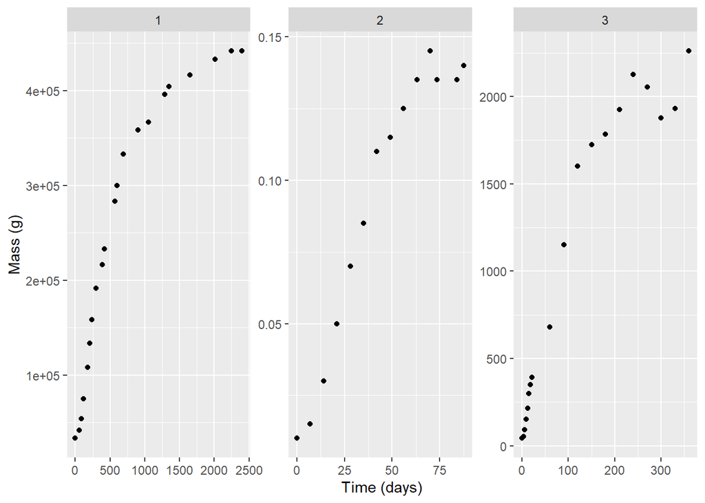

```r
ggplot(GC,aes(Time,Mass))+
  geom_point()+
  facet_wrap(~Number,scales = "free")+
  labs(x="Time (days)",
       y="Mass (g)",
       fill=NULL,color=NULL)
```

先进行第一组数据α=3/4时的公式拟合尝试，核对结果图是否与文献一样。

```r
d_1<-filter(GC,Number=="1")
d_1
```

```
##    Time      Mass Number    a      M
## 1     0  33333.33      1 0.28 442000
## 2    60  41666.67      1 0.28 442000
## 3    90  54166.67      1 0.28 442000
## 4   120  75000.00      1 0.28 442000
## 5   180 108333.33      1 0.28 442000
## 6   210 133333.33      1 0.28 442000
## 7   240 158333.33      1 0.28 442000
## 8   300 191666.67      1 0.28 442000
## 9   390 216666.67      1 0.28 442000
## 10  420 233333.33      1 0.28 442000
## 11  570 283333.33      1 0.28 442000
## 12  600 300000.00      1 0.28 442000
## 13  690 333333.33      1 0.28 442000
## 14  900 358333.33      1 0.28 442000
## 15 1050 366666.67      1 0.28 442000
## 16 1290 395833.33      1 0.28 442000
## 17 1350 404166.67      1 0.28 442000
## 18 1650 416666.67      1 0.28 442000
## 19 2010 433333.33      1 0.28 442000
## 20 2250 441666.67      1 0.28 442000
## 21 2400 441666.67      1 0.28 442000
```

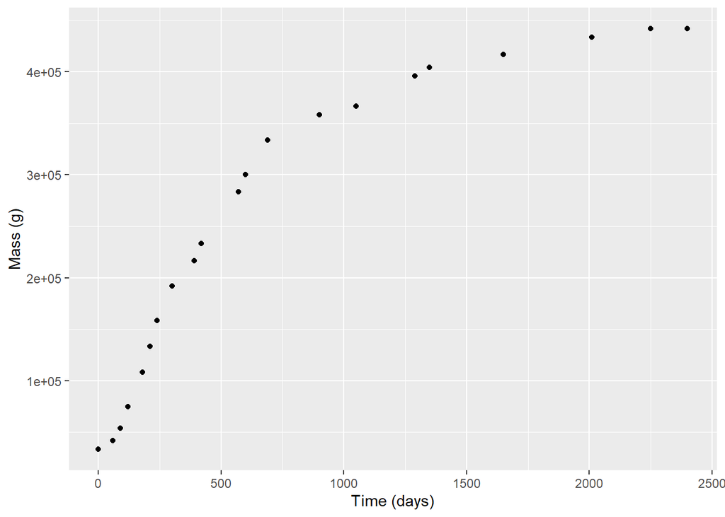

```r
ggplot(d_1,aes(Time,Mass))+
  geom_point()+
  labs(x="Time (days)",
       y="Mass (g)",
       fill=NULL,color=NULL)
```

```r
m0_1<-GC$Mass[1]
m0_1
```

```
## [1] 33333.33
```

```r
a0_1<-GC$a[1]
M0_1<-GC$M[1]

fit_1<-nls(Mass~M*(1-(1-(m0_1/M)^(1/4))*exp(-a*Time/4/M^(1/4)))^4,
    data=d_1,
    start=list(a=a0_1,M=M0_1)
    )

summary(fit_1)
```

```
##
## Formula: Mass ~ M * (1 - (1 - (m0_1/M)^(1/4)) * exp(-a * Time/4/M^(1/4)))^4
##
## Parameters:
##    Estimate Std. Error t value Pr(>|t|)
## a 2.888e-01  7.707e-03   37.48   <2e-16 ***
## M 4.286e+05  5.061e+03   84.68   <2e-16 ***
## ---
## Signif. codes:  0 '***' 0.001 '**' 0.01 '*' 0.05 '.' 0.1 ' ' 1
##
## Residual standard error: 11400 on 19 degrees of freedom
##
## Number of iterations to convergence: 4
## Achieved convergence tolerance: 8.121e-06
```

```r
summary(fit_1)$coefficients
```

```
##       Estimate   Std. Error  t value     Pr(>|t|)
## a 2.888340e-01 7.706506e-03 37.47925 2.819623e-19
## M 4.285752e+05 5.060941e+03 84.68290 5.841099e-26
```

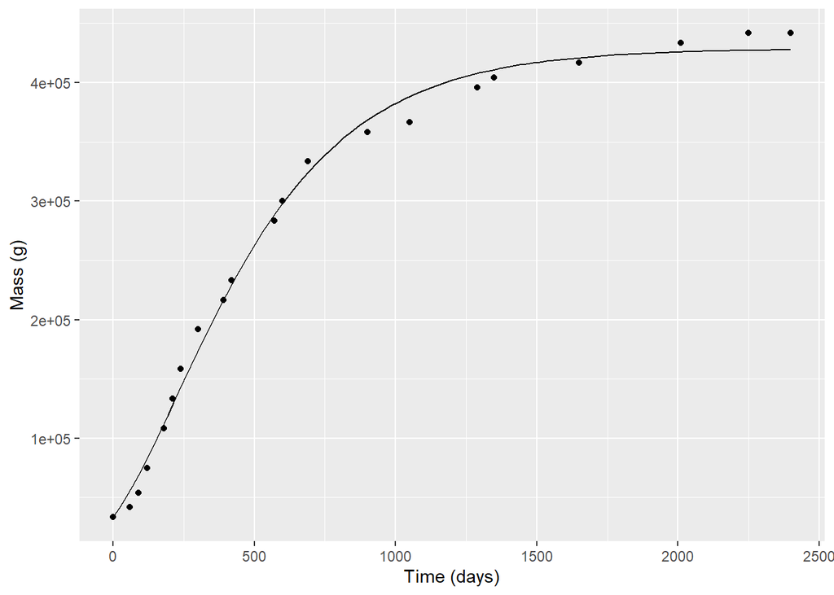

```r
a_1<-summary(fit_1)$coefficients[1]
M_1<-summary(fit_1)$coefficients[2]

ggplot(d_1,aes(Time,Mass))+
  geom_point()+
  geom_function(
    fun=function(x)M_1*(1-(1-(m0_1/M_1)^(1/4))*exp(-a_1*x/4/M_1^(1/4)))^4)+
  labs(x="Time (days)",
       y="Mass (g)",
       fill=NULL,color=NULL)
```

使用循环语句对三组数据进行α=3/4时的公式拟合尝试，并储存拟合结果。

```r
a<-numeric(3)
M<-numeric(3)

for(i in 1:3) {
  d_i<-filter(GC,Number==i)
  m0_i<-d_i$Mass[1]
  a0_i<-d_i$a[1]
  M0_i<-d_i$M[1]
  fit_i<-nls(Mass~M*(1-(1-(m0_i/M)^(1/4))*exp(-a*Time/4/M^(1/4)))^4,
             data=d_i,
             start=list(a=a0_i,M=M0_i)
             )
  a[i]<-summary(fit_i)$coefficients[1]
  M[i]<-summary(fit_i)$coefficients[2]
  }

a
```

```
## [1] 0.28883405 0.09442128 0.47711134
```

```r
M
```

```
## [1] 4.285752e+05 1.567168e-01 2.067490e+03
```

将拟合结果的所需数据分别赋给相应向量，用于计算Mass， 部分数据还将用于后续计算d图的Dimensionless mass ratio和Dimensionless time。

```r
Time<-GC$Time
Time
```

```
##  [1]    0.0   60.0   90.0  120.0  180.0  210.0  240.0  300.0  390.0  420.0
## [11]  570.0  600.0  690.0  900.0 1050.0 1290.0 1350.0 1650.0 2010.0 2250.0
## [21] 2400.0    0.0    7.0   14.0   21.0   28.0   35.0   42.0   49.0   56.0
## [31]   63.0   70.0   73.5   87.5   84.0    0.0    3.0    6.0    9.0   12.0
## [41]   15.0   18.0   21.0   60.0   90.0  120.0  150.0  180.0  210.0  240.0
## [51]  270.0  300.0  330.0  360.0
```

```r
length(Time)
```

```
## [1] 54
```

```r
a_all<-c(rep(a[1],21),rep(a[2],14),rep(a[3],19))
a_all
```

```
##  [1] 0.28883405 0.28883405 0.28883405 0.28883405 0.28883405 0.28883405
##  [7] 0.28883405 0.28883405 0.28883405 0.28883405 0.28883405 0.28883405
## [13] 0.28883405 0.28883405 0.28883405 0.28883405 0.28883405 0.28883405
## [19] 0.28883405 0.28883405 0.28883405 0.09442128 0.09442128 0.09442128
## [25] 0.09442128 0.09442128 0.09442128 0.09442128 0.09442128 0.09442128
## [31] 0.09442128 0.09442128 0.09442128 0.09442128 0.09442128 0.47711134
## [37] 0.47711134 0.47711134 0.47711134 0.47711134 0.47711134 0.47711134
## [43] 0.47711134 0.47711134 0.47711134 0.47711134 0.47711134 0.47711134
## [49] 0.47711134 0.47711134 0.47711134 0.47711134 0.47711134 0.47711134
```

```r
length(a_all)
```

```
## [1] 54
```

```r
M_all<-c(rep(M[1],21),rep(M[2],14),rep(M[3],19))
M_all
```

```
##  [1] 4.285752e+05 4.285752e+05 4.285752e+05 4.285752e+05 4.285752e+05
##  [6] 4.285752e+05 4.285752e+05 4.285752e+05 4.285752e+05 4.285752e+05
## [11] 4.285752e+05 4.285752e+05 4.285752e+05 4.285752e+05 4.285752e+05
## [16] 4.285752e+05 4.285752e+05 4.285752e+05 4.285752e+05 4.285752e+05
## [21] 4.285752e+05 1.567168e-01 1.567168e-01 1.567168e-01 1.567168e-01
## [26] 1.567168e-01 1.567168e-01 1.567168e-01 1.567168e-01 1.567168e-01
## [31] 1.567168e-01 1.567168e-01 1.567168e-01 1.567168e-01 1.567168e-01
## [36] 2.067490e+03 2.067490e+03 2.067490e+03 2.067490e+03 2.067490e+03
## [41] 2.067490e+03 2.067490e+03 2.067490e+03 2.067490e+03 2.067490e+03
## [46] 2.067490e+03 2.067490e+03 2.067490e+03 2.067490e+03 2.067490e+03
## [51] 2.067490e+03 2.067490e+03 2.067490e+03 2.067490e+03
```

```r
length(M_all)
```

```
## [1] 54
```

```r
m0_all<-c(rep(GC$Mass[1],21),rep(GC$Mass[22],14),rep(GC$Mass[36],19))
m0_all
```

```
##  [1] 33333.33 33333.33 33333.33 33333.33 33333.33 33333.33 33333.33 33333.33
##  [9] 33333.33 33333.33 33333.33 33333.33 33333.33 33333.33 33333.33 33333.33
## [17] 33333.33 33333.33 33333.33 33333.33 33333.33     0.01     0.01     0.01
## [25]     0.01     0.01     0.01     0.01     0.01     0.01     0.01     0.01
## [33]     0.01     0.01     0.01    43.00    43.00    43.00    43.00    43.00
## [41]    43.00    43.00    43.00    43.00    43.00    43.00    43.00    43.00
## [49]    43.00    43.00    43.00    43.00    43.00    43.00
```

根据拟合结果计算α=3/4时的Mass。

```r
Mass<-M_all*(1-(1-(m0_all/M_all)^(1/4))*exp(-a_all*Time/4/M_all^(1/4)))^4
Mass
```

```
##  [1] 3.333333e+04 5.613977e+04 6.922069e+04 8.314098e+04 1.126700e+05
##  [6] 1.278937e+05 1.431955e+05 1.734682e+05 2.164581e+05 2.298466e+05
## [11] 2.881797e+05 2.980655e+05 3.243054e+05 3.682445e+05 3.882942e+05
## [16] 4.077409e+05 4.109352e+05 4.209421e+05 4.257998e+05 4.271637e+05
## [21] 4.276504e+05 1.000000e-02 2.278302e-02 3.889709e-02 5.617868e-02
## [26] 7.296038e-02 8.822714e-02 1.015069e-01 1.126976e-01 1.219139e-01
## [31] 1.293772e-01 1.353458e-01 1.378500e-01 1.453399e-01 1.437946e-01
## [36] 4.300000e+01 5.946281e+01 7.906207e+01 1.017835e+02 1.275506e+02
## [41] 1.562346e+02 1.876652e+02 2.216401e+02 7.866913e+02 1.205117e+03
## [46] 1.518505e+03 1.729277e+03 1.863078e+03 1.945322e+03 1.994954e+03
## [51] 2.024588e+03 2.042173e+03 2.052570e+03 2.058704e+03
```

```r
length(Mass)
```

```
## [1] 54
```

由于作者在文中表示，取γ2/3与γ3/4的值相等，且在α=2/3时并没有对M或γ进行拟合， 故可直接将α=3/4时的拟合结果用于计算γ，进而计算α=2/3时的Mass。

```r
ra<-a_all/4/M_all^(1/4)

Mass2<-M_all*(1-(1-(m0_all/M_all)^(1/3))*exp(-ra*Time))^3
Mass2
```

```
##  [1] 3.333333e+04 5.892783e+04 7.343159e+04 8.869678e+04 1.205107e+05
##  [6] 1.366296e+05 1.526522e+05 1.838658e+05 2.272064e+05 2.404924e+05
## [11] 2.973499e+05 3.068332e+05 3.318099e+05 3.730428e+05 3.916299e+05
## [16] 4.095304e+05 4.124591e+05 4.216134e+05 4.260459e+05 4.272891e+05
## [21] 4.277327e+05 1.000000e-02 2.444140e-02 4.203662e-02 6.019945e-02
## [26] 7.726739e-02 9.239084e-02 1.052774e-01 1.159644e-01 1.246579e-01
## [31] 1.316314e-01 1.371677e-01 1.394802e-01 1.463613e-01 1.449458e-01
## [36] 4.300000e+01 6.308000e+01 8.713940e+01 1.149819e+02 1.463449e+02
## [41] 1.809211e+02 2.183770e+02 2.583661e+02 8.692781e+02 1.280706e+03
## [46] 1.574540e+03 1.766733e+03 1.886771e+03 1.959855e+03 2.003713e+03
## [51] 2.029814e+03 2.045273e+03 2.054402e+03 2.059785e+03
```

将数据按不同物种分开储存。

```r
Mass0<-GC$Mass
Mass0_cow<-Mass0[1:21]/1000
Mass_cow<-Mass[1:21]/1000
Mass2_cow<-Mass2[1:21]/1000
cow_data<-data.frame(Time[1:21],Mass0_cow,Mass_cow,Mass2_cow)
guppy_data<-data.frame(Time[22:35],Mass0[22:35],Mass[22:35],Mass2[22:35])
hen_data<-data.frame(Time[36:54],Mass0[36:54],Mass[36:54],Mass2[36:54])

names(cow_data)
```

```
## [1] "Time.1.21." "Mass0_cow"  "Mass_cow"   "Mass2_cow"
```

分别绘制三个物种的两种拟合曲线图，将绘图结果储存。

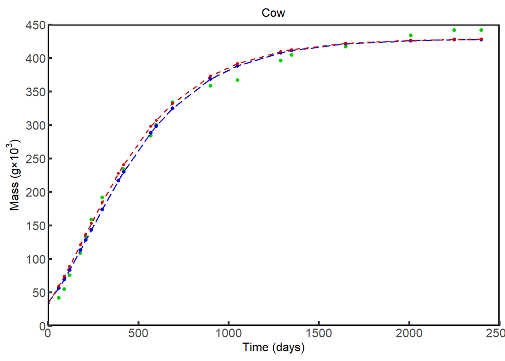

```r
p1<-ggplot()+
  geom_point(data=cow_data,aes(Time[1:21],Mass0_cow),
             size=1.5,color="green3")+
  geom_point(data=cow_data,aes(Time[1:21],Mass_cow),
             size=1.5,color="blue3")+
  geom_line(data=cow_data,aes(Time[1:21],Mass_cow),
            color="blue3",linewidth=0.7,linetype=5)+
  geom_point(data=cow_data,aes(Time[1:21],Mass2_cow),
             size=1,color="red3")+
  geom_line(data=cow_data,aes(Time[1:21],Mass2_cow),
            color="red3",linewidth=0.7,linetype=2)+
  labs(x="Time (days)",
       y=expression("Mass ("*g*"×10"^3*")"),
       title="Cow",
       fill=NULL,color=NULL)+
  scale_x_continuous(limits=c(0,2500),expand=c(0,0),
                     breaks=seq(0,2500,by=500))+
  scale_y_continuous(limits=c(0,450),expand=c(0,0),
                     breaks=seq(0,450,by=50))+
  theme(axis.ticks.length.x=unit(-0.15,'cm'),
        axis.ticks.length.y=unit(-0.15,'cm'),
        axis.ticks=element_line(linewidth=1),
        axis.text=element_text(size=12,family="sans"),
        axis.title=element_text(size=12,family="sans"),
        plot.title=element_text(size=12,family="sans",hjust=0.5),
        panel.border=element_rect(linewidth=1.2,fill="transparent"),
        panel.background=element_blank(),
        strip.background=element_blank(),
        aspect.ratio=1/1.5)
p1
```

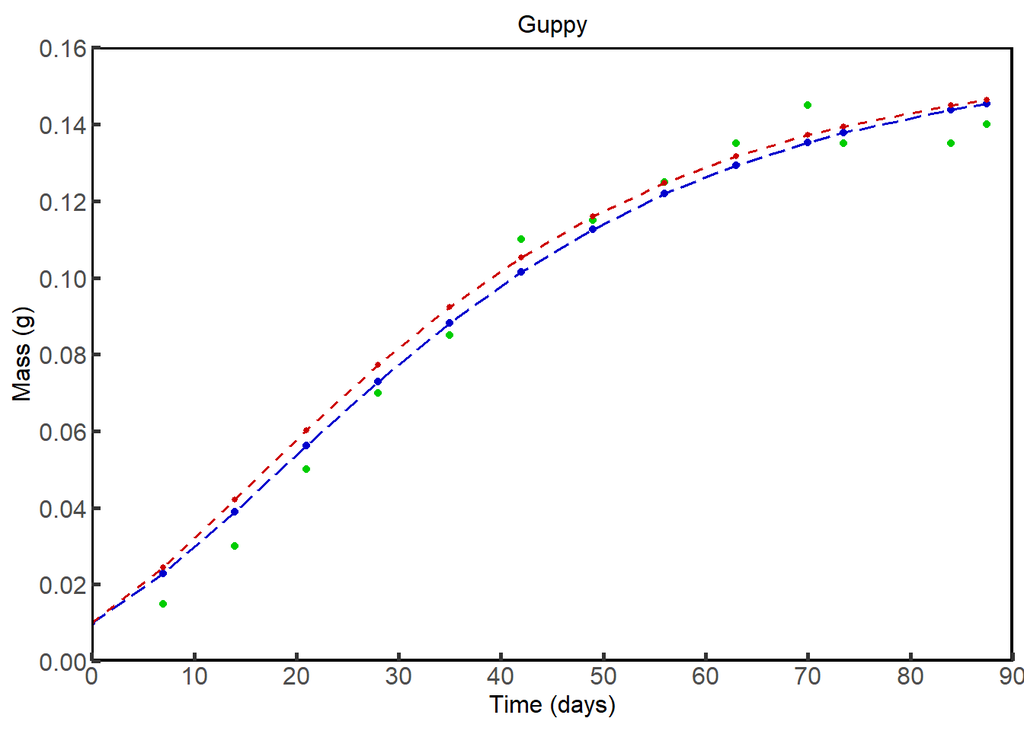

```r
p2<-ggplot()+
  geom_point(data=guppy_data,aes(Time[22:35],Mass0[22:35]),
             size=1.5,color="green3")+
  geom_point(data=guppy_data,aes(Time[22:35],Mass[22:35]),
             size=1.5,color="blue3")+
  geom_line(data=guppy_data,aes(Time[22:35],Mass[22:35]),
            color="blue3",linewidth=0.7,linetype=5)+
  geom_point(data=guppy_data,aes(Time[22:35],Mass2[22:35]),
             size=1,color="red3")+
  geom_line(data=guppy_data,aes(Time[22:35],Mass2[22:35]),
            color="red3",linewidth=0.7,linetype=2)+
  labs(x="Time (days)",
       y="Mass (g)",
       title="Guppy",
       fill=NULL,color=NULL)+
  scale_x_continuous(limits=c(0,90),expand=c(0,0),
                     breaks=seq(0,90,by=10))+
  scale_y_continuous(limits=c(0,0.16),expand=c(0,0),
                     breaks=seq(0,0.16,by=0.02))+
  theme(axis.ticks.length.x=unit(-0.15,'cm'),
        axis.ticks.length.y=unit(-0.15,'cm'),
        axis.ticks=element_line(linewidth=1),
        axis.text=element_text(size=12,family="sans"),
        axis.title=element_text(size=12,family="sans"),
        plot.title=element_text(size=12,family="sans",hjust=0.5),
        panel.border=element_rect(linewidth=1.2,fill="transparent"),
        panel.background=element_blank(),
        strip.background=element_blank(),
        aspect.ratio=1/1.5)
p2
```

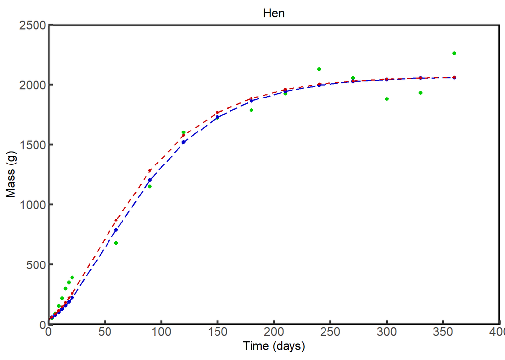

```r
p3<-ggplot()+
  geom_point(data=hen_data,aes(Time[36:54],Mass0[36:54]),
             size=1.5,color="green3")+
  geom_point(data=hen_data,aes(Time[36:54],Mass[36:54]),
             size=1.5,color="blue3")+
  geom_line(data=hen_data,aes(Time[36:54],Mass[36:54]),
            color="blue3",linewidth=0.7,linetype=5)+
  geom_point(data=hen_data,aes(Time[36:54],Mass2[36:54]),
             size=1,color="red3")+
  geom_line(data=hen_data,aes(Time[36:54],Mass2[36:54]),
            color="red3",linewidth=0.7,linetype=2)+
  labs(x="Time (days)",
       y="Mass (g)",
       title="Hen",
       fill=NULL,color=NULL)+
  scale_x_continuous(limits=c(0,400),expand=c(0,0),
                     breaks=seq(0,400,by=50))+
  scale_y_continuous(limits=c(0,2500),expand=c(0,0),
                     breaks=seq(0,2500,by=500))+
  theme(axis.ticks.length.x=unit(-0.15,'cm'),
        axis.ticks.length.y=unit(-0.15,'cm'),
        axis.ticks=element_line(linewidth=1),
        axis.text=element_text(size=12,family="sans"),
        axis.title=element_text(size=12,family="sans"),
        plot.title=element_text(size=12,family="sans",hjust=0.5),
        panel.border=element_rect(linewidth=1.2,fill="transparent"),
        panel.background=element_blank(),
        strip.background=element_blank(),
        aspect.ratio=1/1.5)
p3
```

根据文献中提供的公式分别计算Dimensionless mass ratio和Dimensionless time， 其中，三个物种的数据为，取两种拟合结果，根据r和τ各自的公式分别计算， 而用于绘制通用曲线的数据为，取三个物种全部的τ值， 利用r和τ之间的关系公式计算出r值，将计算结果储存。

```r
mr1<-
  (Mass0[1:21]/M_all[1:21])^(1/4)
tr1<-
  -log((1-(m0_all[1:21]/M_all[1:21])^(1/4))*exp(-ra[1:21]*Time[1:21]))
mr2<-
  (Mass0[1:21]/M_all[1:21])^(1/3)
tr2<-
  -log((1-(m0_all[1:21]/M_all[1:21])^(1/3))*exp(-ra[1:21]*Time[1:21]))
mr_cow<-c(mr1,mr2)
tr_cow<-c(tr1,tr2)

mr3<-
  (Mass0[22:35]/M_all[22:35])^(1/4)
tr3<-
  -log((1-(m0_all[22:35]/M_all[22:35])^(1/4))*exp(-ra[22:35]*Time[22:35]))
mr4<-
  (Mass0[22:35]/M_all[22:35])^(1/3)
tr4<-
  -log((1-(m0_all[22:35]/M_all[22:35])^(1/3))*exp(-ra[22:35]*Time[22:35]))
mr_guppy<-c(mr3,mr4)
tr_guppy<-c(tr3,tr4)

mr5<-
  (Mass0[36:54]/M_all[36:54])^(1/4)
tr5<-
  -log((1-(m0_all[36:54]/M_all[36:54])^(1/4))*exp(-ra[36:54]*Time[36:54]))
mr6<-
  (Mass0[36:54]/M_all[36:54])^(1/3)
tr6<-
  -log((1-(m0_all[36:54]/M_all[36:54])^(1/3))*exp(-ra[36:54]*Time[36:54]))
mr_hen<-c(mr5,mr6)
tr_hen<-c(tr5,tr6)

tr<-c(tr1,tr2,tr3,tr4,tr5,tr6)
mr<-1-exp(-tr)
p4_data<-data.frame(mr,tr)

cow<-data.frame(mr_cow,tr_cow)
guppy<-data.frame(mr_guppy,tr_guppy)
hen<-data.frame(mr_hen,tr_hen)
```

绘制d图，将绘图结果储存。

```r
p4<-ggplot()+
  geom_function(data=p4_data,aes(tr),
                fun=function(x)1-exp(-(x)),
                color="black",linewidth=1,linetype=3,alpha=0.5)+
  scale_x_continuous(limits=c(0,8),expand=c(0,0),
                     breaks=seq(0,8,by=1))+
  scale_y_continuous(limits=c(0,1.2),expand=c(0,0),
                     breaks=seq(0,1.2,by=0.2))+
  geom_point(data=cow,aes(tr_cow,mr_cow),size=1.5,color="green3")+
  geom_point(data=hen,aes(tr_hen,mr_hen),size=1.5,color="blue3")+
  geom_point(data=guppy,aes(tr_guppy,mr_guppy),size=1.5,color="red3")+
  labs(x="Dimensionless time",
       y="Dimensionless mass ratio",
       title="Scaling collapse",
       fill=NULL,color=NULL)+
  theme(axis.ticks.length.x=unit(-0.15,'cm'),
        axis.ticks.length.y=unit(-0.15,'cm'),
        axis.ticks=element_line(linewidth=1),
        axis.text=element_text(size=12,family="sans"),
        axis.title=element_text(size=12,family="sans"),
        plot.title=element_text(size=12,family="sans",hjust=0.5),
        panel.border=element_rect(linewidth=1.2,fill="transparent"),
        panel.background=element_blank(),
        strip.background=element_blank(),
        aspect.ratio=1/1.5)

?windowsFont()
```

```
## 打开httpd帮助服务器… 好了
```

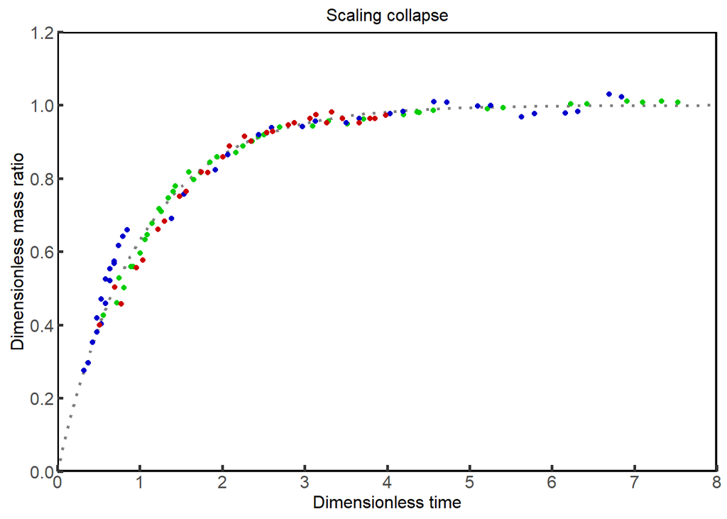

```r
p4
```

将四张图像进行组合，存储结果，输出目标图像。

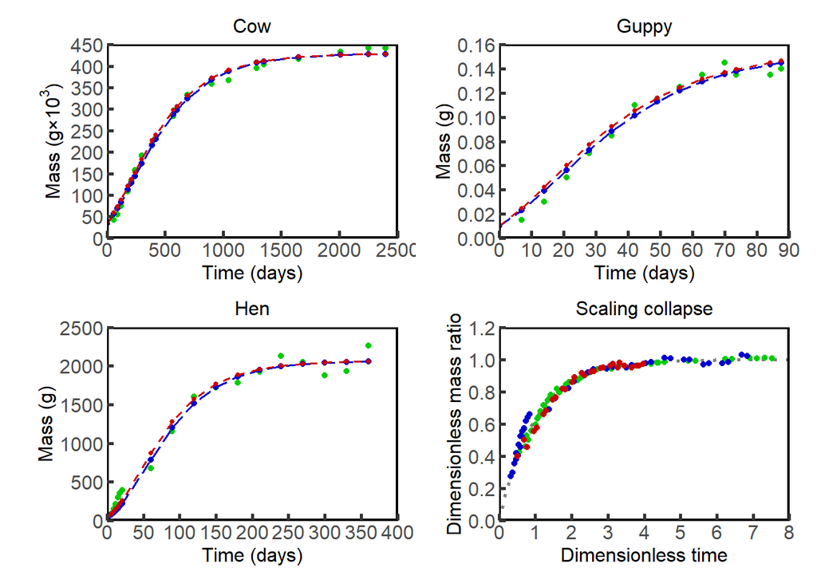

```r
library(patchwork)

plot<-(p1+p2+p3+p4)+
  plot_layout(ncol=2,heights=c(1,1),widths=c(1,1))
plot
```